# Sesión 21

David Nexticapan Cortes

2025-03-13

1. La aseveración es que la proporción de adultos que fumaron un cigarrillo la semana pasada es menor que 0.25, y los estadísticos de muestra incluyen 𝑛=1018 sujetos, de los cuales 224 dicen que fumaron un cigarrillo la semana pasada.

Planteamos el juego de hipótesis

$$H_0: p \geq 0.25\\
H_1: p < 0.25$$

```r
estadistico_proporciones <- function(p_hat, p, n){
  z <- round((p_hat - p) / sqrt(p * (1 - p) / n),2)
  return(z)
}
```

```r
estadistico_proporciones(p_hat = 224/1018, p = 0.25, n = 1018)
```

```
## [1] -2.21
```

2. La aseveración es que la mayoría de las demandas por negligencia se retiran o se rechazan, y una muestra aleatoria de 500 demandas incluye 349 que fueron retiradas o rechazadas.

$$H_0: p \leq 0.50\\
H_1: p > 0.50$$

```r
estadistico_proporciones(p_hat = 349/500, p = 0.50, n = 500)
```

```
## [1] 8.85
```

# **Valor crítico**

Actividad: Con un nivel de significancia de 𝛼=0.05, calcule los valores 𝑧 críticos para cada una de las siguientes hipótesis alternativas.

Caso 1: 𝑝≠0.5 (de manera que la región crítica está en ambas colas de la distribución normal)

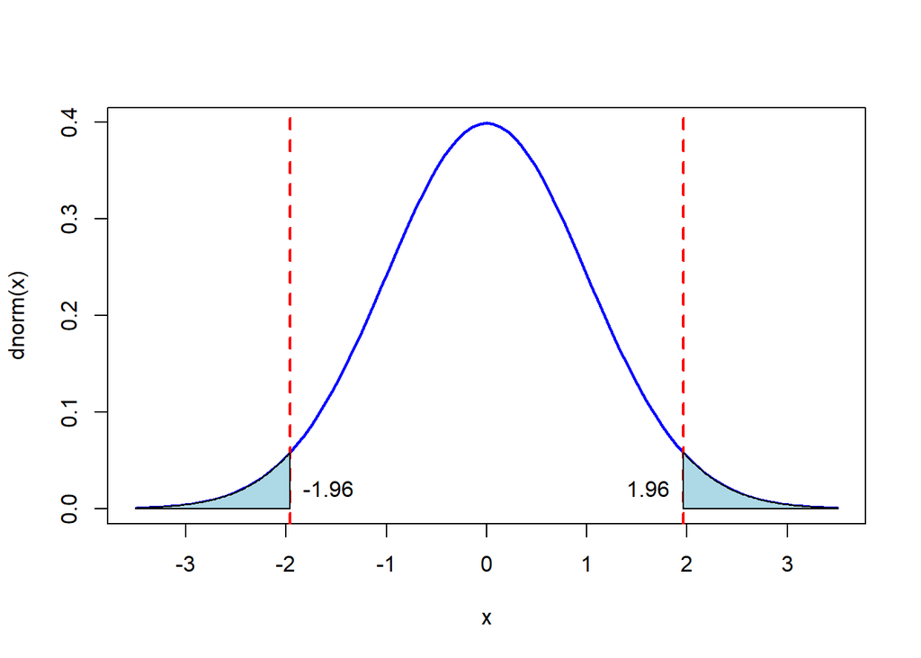

```r
# dnorm
# pnorm
# qnorm
# rnorm
alpha <- 0.05
critico_izq <- round(qnorm(p = alpha /2, lower.tail = T),4)
critico_der <- round(qnorm(p = 1 - alpha /2, lower.tail = T),4)

# Graficar la curva de densidad de la normal estándar.
curve(dnorm(x), from = -3.5, to = 3.5, col = "blue", lwd = 2)

# Colocamos lineas verticales en la posición de los valores críticos
abline(v = critico_izq, col = "red", lwd = 2, lty = 2)
abline(v = critico_der, col = "red", lwd = 2, lty = 2)

# Rellenamos el área de la cola izquierda
x_valores <- seq(-3.5, critico_izq, length.out = 100)
y_valores <- dnorm(x_valores)
polygon(c(-3.5, x_valores, critico_izq), c(0, y_valores, 0), col = "lightblue")

# Rellenar el área de la cola derecha
x_valores <- seq(critico_der, 3.5, length.out = 100)
y_valores <- dnorm(x_valores)
polygon(c(critico_der, x_valores, 3.5), c(0, y_valores, 0), col = "lightblue")

# Colocamos el texto del valor de los valores críticos
text(x = critico_izq, y = 0.02, labels = critico_izq, pos = 4)
text(x = critico_der, y = 0.02, labels = critico_der, pos = 2)
```

Caso 2: 𝑝<0.5 (de manera que la región crítica está en la cola izquierda de la distribución normal)

```r
v_critico <- round(qnorm(p = alpha, lower.tail = T),4)
v_critico
```

```
## [1] -1.6449
```

Caso 3: 𝑝>0.5 (de manera que la región crítica está en la cola derecha de la distribución normal)

```r
v_critico <- round(qnorm(p = 1 - alpha, lower.tail = T),4)
v_critico
```

```
## [1] 1.6449
```

# **p_value**

Caso 1: Se utiliza un nivel de significancia de 𝛼=0.05 para probar la aseveración de que 𝑝>0.25. Considera que los datos muestrales dan por resultado un estadístico de prueba de 𝑧=1.18.

```r
# Tipo de prueba: Cola derecha
p_value <- pnorm(q = 1.18, lower.tail = F)
p_value
```

```
## [1] 0.1190001
```

Caso 2: Se utiliza un nivel de significancia de 𝛼=0.05 para probar la aseveración de que 𝑝≠0.25, y los datos muestrales dan por resultado un estadístico de prueba de 𝑧=2.34.

```r
# Tipo de prueba: Dos colas
p_value <- 2 * pnorm(q = 2.34, lower.tail = F)
p_value
```

```
## [1] 0.01928374
```